# Problem 5: Market Segmentation

```
## hc_clust_avg
##    1    2    3    4    5    6    7    8    9   10   11
## 1067  279  551   32 2474  414  765 1054  547  426  273
```

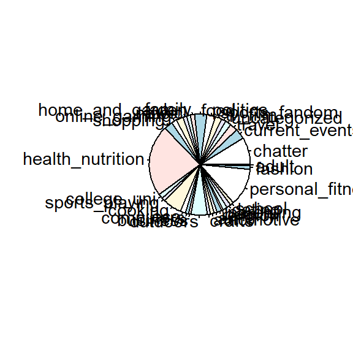

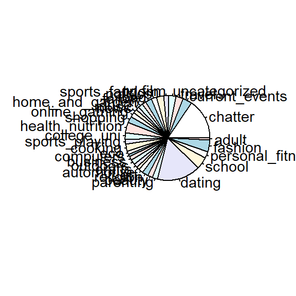

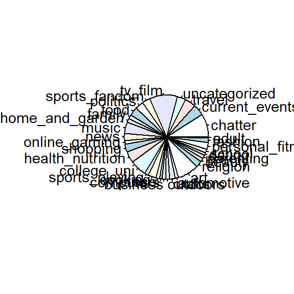

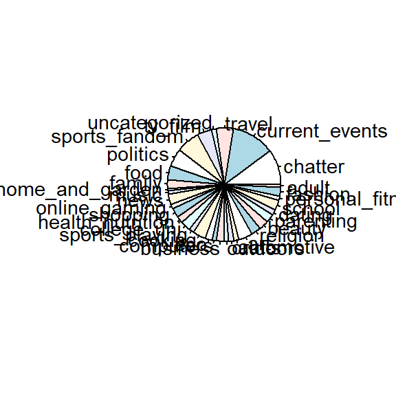

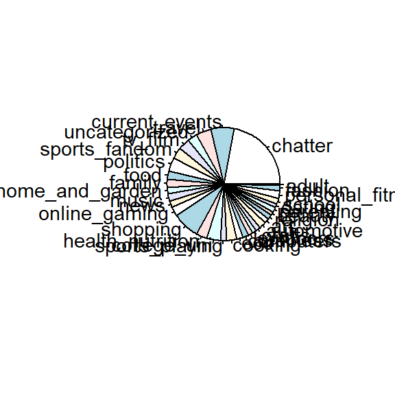

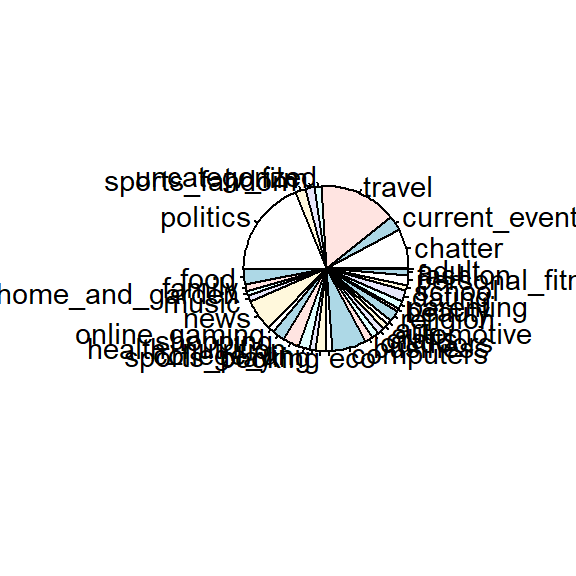

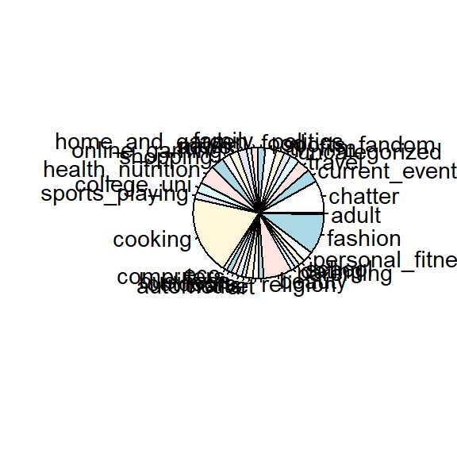

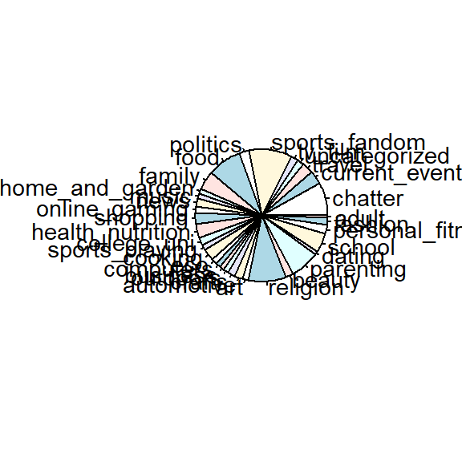

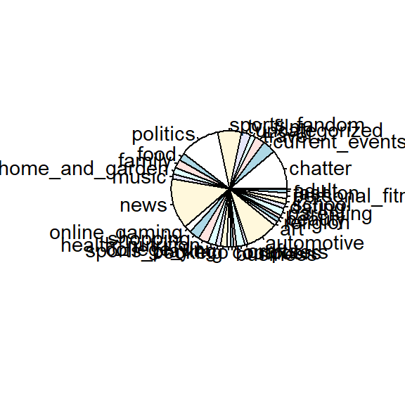

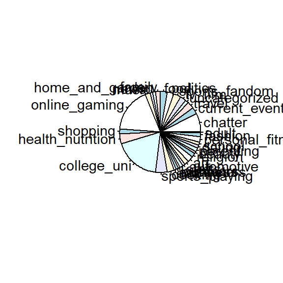

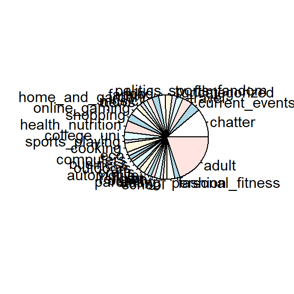

### Insights and Recommendations

The comprehensive approach described above was the analysis that went into uncovering insights that could be beneficial for NutrientH2O for the purposes of providing meaningful market segmentation. We used a cluster approach to define various market segments from the social media data presented.

The most desired insight to uncover is to explicitly state the distinct market segments that emerged from the analysis. Based on the K-Means and Hierarchical Clustering algorithms, there were a total of 9 Market Segments derived:

1. Dating, School, Fashion, Photo Sharing
2. Food, Religion, Parenting, Sports Fandom
3. Politics, Travel, News, Computers
4. Photo Sharing, Shopping, Current Events, Travel
5. Cooking, Photo Sharing, Beauty, Fashion
6. Online Gaming, College/University, Sports Playing
7. TV & Film, College/University, Music
8. Health & Nutrition, Personal Fitness, Cooking, Outdoors
9. News, Automotive, Politics, Sports Fandom

With this Market Segmentation knowledge in mind, NutrientH2O can design specific marketing campaigns to these 9 distinct audience members.

For example, it is highly likely that the demographic information for segment #5 - ‘Cooking, Photo Sharing, Beauty, Fashion’ is vastly different than the demographic makeup of segment #6 - ‘Online Gaming, College/University, Sports Playing’. More specifically, based on substantive knowledge of those subject matters, it is fair to assume that segment #5 is comprised of a larger female population than segment #6. Therefore, NutrientH2O can use this market segmentation knowledge to their advantage by designing two separate marketing campaigns to address members of each segment #5 and #6 to convey the most compelling message.

Insights such as the one descrived can be invalubale to a firm in terms of strategic marketing, and we were able to leverage clustering algorithms for the purposes of identifying market segments. Our analysis was not only thorough, but also confirmed some of the initial intuition we had when first evaluating the dataset, and can be used by NutrientH2O to increase profitability.